# rmap—v-0.02-01–2017-05-24 04:37:31 PDT

# 1 Introduction

Personal predictive models use an individual’s personal covariates to assign him/her a probability of developing a specific disease, within a specified future time period $[0, \text{t_star})$ and before a competing risk. The models are often evaluated by comparing their assigned risks to outcome incidences among participants in a cohort study. Performance of such models are evaluated using two criteria: calibration and concordance.

This package provides the functions `calibration` and `concordance` for evaluating the performance of personal predictive models.

Both functions allow for unweighted and weighted sampling designs. `calibration` also allows for two-stage sampling design.

TOP

# 2 Data preparation

We assume that you have a data set containing $N$ people, and for the $n$-th person, you have recorded $(e_n, t_n, r_n)$ organized into a `data.frame`, one row for each person, containing the following columns.

## 2.1 `e`

The event for the subject. Record`e = 1` if the adverse outcome was observed to occur before `t_star` and before the competing event, `e = 2` if the competing risk, such as death from other causes, was observed to occur before `t_star` and before the adverse outcome, and `0` if censored or free from adverse outcome and competing risk at time `t_star`. Acceptable values are `0, 1, 2`.

## 2.2 `t`

The time until event. Mathematically speaking, let `t_1` be time until adverse outcome, `t_2` time until competing risk, `t_0` ($\le$ `t_star`) time until censoring . Then `t` is the minimum of `t_1`, `t_2`, `t_0`, `t_star`. And `e` records which of the events occurred first. Acceptable values are `[0, t_star]` (real numbers between `0` and `t_star`, including `0` and `t_star`).

## 2.3 `r`

The risk assigned by the personal predictive model. This is the probability of adverse outcome occuring before the competing risk and within `[0, t_star)`. Acceptable values are `[0, 1]` (real numbers between `0` and `1`, including `0` and `1`).

## 2.4 `category` (optional)

If your data were obtained by two-stage sampling, this is the two-stage category indicating which two-stage category the person fell into. If there were `C` possible categories, acceptable values are `1`, `2`, $\cdots$, `C`.

## 2.5 `weight` (optional)

If your data sample does not represent the target population, and you would like to weight your sample to more closely match the target population, provide this `weight` column. Acceptable values are `(0, 1]` (real numbers between `0` and `1`, not including `0` but including `1`.

TOP

# 3 Installing rmap

If you have not yet installed R, download the latest version (at least 3.3.1) for your operating system at:

http://www.r-project.org

Run the R application. To install the rmap package, enter the following lines of code to the R prompt:

```
install.packages("devtools")
library(devtools)
install_github("gailg/rmap")
if("rmap" %in% rownames(installed.packages())){
  print("rmap installed successfully--you are good to go!")
} else {
  print("something went wrong--ask for help")
}
```

If your installation was successful, you should see the message

```
[1] "rmap installed successfully--you are good to go!"
```

TOP

# 4 Reading in data

```r
x = read.csv(
    file = "datafRandomSample.csv",
    stringsAsFactors = FALSE)
head(x)
```

```
##   e           t          w          r c k
## 1 2 2.561438270 0.12866006 0.50549600 A 2
## 2 0 0.095180473 0.17789840 0.60040155 A 3
## 3 1 5.345122849 0.11833314 0.48092134 A 2
## 4 2 2.384192874 0.31289498 0.74560713 A 5
## 5 1 1.243401695 0.18858680 0.61701527 A 4
## 6 2 1.377850831 0.11905290 0.48269588 A 2
```

```r
library(rmap)
set.seed(42)
df1 = df_randomSample(KKK = 4)
x = rmap_random_sample = df1[, c("e", "t", "r", "k")]
head(x)
```

```
##     e          t          r k
## 980 1 1.30073009 0.72535682 4
## 647 1 0.62579723 0.51277814 2
## 59  2 3.93047047 0.62080826 3
## 906 2 0.18107425 0.65065442 3
## 269 1 1.76518687 0.62542930 3
## 18  2 4.12849499 0.56679208 2
```

```r
riskValidate(e = x$e, t = x$t, r = x$r,
             design = "randomSample",
             riskGroup = list(k = x$k),
                          rSummary = "mean",
                          bootstrap = FALSE, rvpar = rvparFn(col = "darkgreen"))
```

```
## [1] "Loading 'grid' package"
## [1] "Done loading 'grid' package"
```

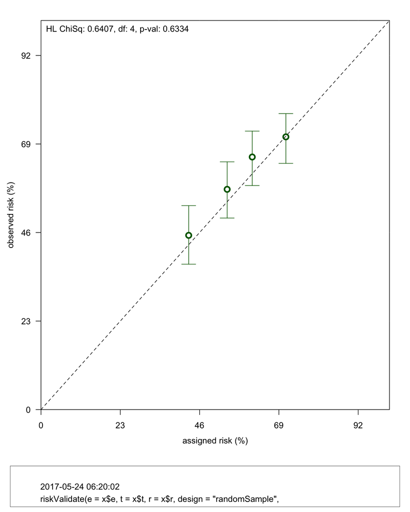

```
## $gammaHat
## [1] 0.25 0.25 0.25 0.25
##
## $piHat
##         k1         k2         k3         k4
## 0.45267381 0.57221937 0.65618173 0.70853733
##
## $Sigma
##         [,1]    [,2]    [,3]      [,4]     [,5]     [,6]      [,7]
## [1,]  0.1875 -0.0625 -0.0625 0.0000000 0.000000 0.000000 0.0000000
## [2,] -0.0625  0.1875 -0.0625 0.0000000 0.000000 0.000000 0.0000000
## [3,] -0.0625 -0.0625  0.1875 0.0000000 0.000000 0.000000 0.0000000
## [4,]  0.0000  0.0000  0.0000 1.5284852 0.000000 0.000000 0.0000000
## [5,]  0.0000  0.0000  0.0000 0.0000000 1.407719 0.000000 0.0000000
## [6,]  0.0000  0.0000  0.0000 0.0000000 0.000000 1.316017 0.0000000
## [7,]  0.0000  0.0000  0.0000 0.0000000 0.000000 0.000000 1.0954712
##
## $piHatSummary
##             r      piHat       sigma      lower      upper inCI
## k1 0.42838570 0.45267381 0.039095846 0.37773916 0.52981687  yes
## k2 0.53999027 0.57221937 0.037519581 0.49762273 0.64367094  yes
## k3 0.61270451 0.65618173 0.036276949 0.58204223 0.72341932  yes
## k4 0.71027496 0.70853733 0.033097903 0.63972246 0.76895534  yes
##
## $ChiSq
## HosmerLemeshow        HL_pval
##     0.64073212     0.63340163
##
## attr(,"class")
## [1] "rv"   "list"
```

TOP